# voting + wellbeing

## Examining Patterns in Voting and Wellbeing in the United States

When complaining about how much life sucks on any social media platform, a common sentiment relayed to the complainer is to "vote more!" Especially around election time. That got us thinking.

We decided to study whether voting percentages were correlated in any way to quality of life. However, eventually we also started wondering if said voting percentages were more dependent on *who* voted rather than *where* they vote. Thus, we decided to investigate these questions by exmaining at voting, demographic, and wellbeing data United States states, to see if there were any insights to be discovered!

### Data Collection & Curation

To start, we will need to find a dataset that can describe some characteristics pertaining to quality of life per state. When searching, we came across some datasets by WalletHub which assigned scores for each of the 50 states on characteristics like happiness, livability, stress, wealth gap between races, and quality of healthcare. They calculated these scores by comparing states across key dimensions and evaluating the states based on a number of metrics pertaining to the dimension. For example, for the 'Livability Score,' researchers examined metrics relating to five key dimensions: Affordability, Economy, Education & Health, Quality of Life, and Safety. Some metrics used to evaluate the Affordability dimension, would thereby include Cost of Living, Median Annual Household Income, Homeownership Rate, and more.

To further clarify, happiness scores describe general life satisfaction and wellness, livability scores describe the best states to live in, stress scores describe general level of stress in each state, wealth gap scores describe economic racial inequality, and healthcare scores describe the quality of healthcare in each state. Their methodology appears to be very thorough, and if we assume their assigned scores are truly reflective of a characteristic of wellbeing/quality of life, we could examine these in relation to voting data!

Thus, to start, we scraped the data for happiness, livability, stress, wealth gap between races, and quality of healthcare using the BeautifulSoup library.

```python
import requests
import pandas as pd
from bs4 import BeautifulSoup
import folium
import geopandas as gpd
from sklearn import linear_model
from sklearn.metrics import r2_score
```

```python
happiness_page = requests.get('https://wallethub.com/edu/happiest-states/6959', headers={'User-Agent':'Mozilla/5.0'})
happy_soup = BeautifulSoup(happiness_page.content, "html")

livability_page = requests.get('https://wallethub.com/edu/best-states-to-live-in/62617', headers={'User-Agent':'Mozilla/5.0'})
life_soup = BeautifulSoup(livability_page.content, "html")

stress_page = requests.get('https://wallethub.com/edu/most-stressful-states/32218', headers={'User-Agent':'Mozilla/5.0'})
stress_soup = BeautifulSoup(stress_page.content, "html")

wealth_gap_page = requests.get('https://wallethub.com/edu/states-with-the-highest-and-lowest-financial-gaps-by-race/9842', headers={'User-Agent':'Mozilla/5.0'})
wealth_gap_soup = BeautifulSoup(wealth_gap_page.content, "html")

healthcare_page = requests.get('https://wallethub.com/edu/states-with-best-health-care/23457', headers={'User-Agent':'Mozilla/5.0'})
healthcare_soup = BeautifulSoup(healthcare_page.content, "html")
```

```python
happiness_matches = happy_soup.findAll('table')[0].findAll('tr')[1:]
livability_matches = life_soup.findAll('table')[0].findAll('tr')[1:]
stress_matches = stress_soup.findAll('table')[0].findAll('tr')[1:]
wealth_gap_matches = wealth_gap_soup.findAll('table')[0].findAll('tr')[1:]
healthcare_matches = healthcare_soup.findAll('table')[0].findAll('tr')[1:]
```

```python
happiness_states = []
happiness_scores = []

livability_states = []
livability_scores = []

stress_states = []
stress_scores = []

wealth_gap_states = []
wealth_gap_scores = []

healthcare_states = []
healthcare_scores = []


for i in range(0, 50):
    happiness_rows = happiness_matches[i].findAll('td')
    happiness_states.append(happiness_rows[1].text)
    happiness_scores.append(float(happiness_rows[2].text))

    livability_rows = livability_matches[i].findAll('td')
    livability_states.append(livability_rows[1].text)
    livability_scores.append(float(livability_rows[2].text))

    stress_rows = stress_matches[i].findAll('td')
    stress_states.append(stress_rows[1].text)
    stress_scores.append(float(stress_rows[2].text))

for i in range(0, 51): #these include DC!
    wealth_gap_rows = wealth_gap_matches[i].findAll('td')
    wealth_gap_states.append(wealth_gap_rows[1].text)
    wealth_gap_scores.append(float(wealth_gap_rows[2].text))

    healthcare_rows = healthcare_matches[i].findAll('td')
    healthcare_states.append(healthcare_rows[1].text)
    healthcare_scores.append(float(healthcare_rows[2].text))
```

```python
state_happiness = {'state': happiness_states, 'happiness_score': happiness_scores}
state_livability = {'state': livability_states, 'livability_score': livability_scores}
state_stress = {'state': stress_states, 'stress_score': stress_scores}
state_wealth_gap = {'state': wealth_gap_states, 'wealth_gap_score': wealth_gap_scores}
state_healthcare = {'state': healthcare_states, 'healthcare_score': healthcare_scores}

state_happiness = pd.DataFrame(state_happiness)
state_livability = pd.DataFrame(state_livability)
state_stress = pd.DataFrame(state_stress)
state_wealth_gap = pd.DataFrame(state_wealth_gap)
state_healthcare = pd.DataFrame(state_healthcare)

wellbeing_scores = pd.merge(state_happiness, state_livability,  how='left', on=['state'])
wellbeing_scores = pd.merge(wellbeing_scores, state_stress, how='left', on=['state'])
wellbeing_scores = pd.merge(wellbeing_scores, state_wealth_gap, how='left', on=['state'])
wellbeing_scores = pd.merge(wellbeing_scores, state_healthcare, how='left', on=['state'])

wellbeing_scores.sort_values('state', inplace=True)
wellbeing_scores.reset_index(drop=True, inplace=True)
wellbeing_scores.head(5)
```

|  | state | happiness_score | livability_score | stress_score | wealth_gap_score | healthcare_score |
| --- | --- | --- | --- | --- | --- | --- |
| 0 | Alabama | 42.99 | 47.52 | 54.61 | 45.77 | 41.46 |
| 1 | Alaska | 44.24 | 40.17 | 49.04 | 25.99 | 50.36 |
| 2 | Arizona | 52.76 | 49.50 | 49.04 | 38.66 | 49.88 |
| 3 | Arkansas | 37.47 | 44.53 | 55.46 | 46.90 | 44.89 |
| 4 | California | 63.82 | 52.32 | 49.08 | 41.18 | 57.11 |

Perfect! As seen above, we have the scores for each of these "wellbeing" characteistics. Now, we need to pull in some voting data. We were able to find a 2018 dataset from the Census which provides voting data information. It also includes details about voter gender and race that may come in handy later, but for now, let us focus on getting just the total registration and voting data.

Upon reading in the dataset, we need to clean it up. First, this census data is a dataset with a multiindex (state and demographic) which can make things tricky. If we want to work with both the wellbeing dataset and census dataset, then we need to rename the states such that we can merge the datasets on state name later. Here, we rename the multiindex names, and the names of the state for ease of use. We also drop DC since it doesn't appear consistently in the wellbeing data.

```python
census_voting_data = pd.read_excel('data/voting_by_sex_and_race.xlsx', index_col=[0,1], header=[0,1])
census_voting_data.index.rename(['state', 'demographic'], inplace=True)

state_propercase = {
    "ALABAMA": "Alabama",
    "ALASKA": "Alaska",
    "ARIZONA":"Arizona",
    "ARKANSAS":"Arkansas",
    "CALIFORNIA":"California",
    "COLORADO":"Colorado",
    "CONNECTICUT":"Connecticut",
    "DELAWARE":"Delaware",
    "DISTRICT OF COLUMBIA": "DC",
    "FLORIDA":"Florida",
    "GEORGIA":"Georgia",
    "HAWAII":"Hawaii",
    "IDAHO":"Idaho",
    "ILLINOIS":"Illinois",
    "INDIANA": "Indiana",
    "IOWA":"Iowa",
    "KANSAS":"Kansas",
    "KENTUCKY":"Kentucky",
    "LOUISIANA":"Louisiana",
    "MAINE":"Maine",
    "MARYLAND":"Maryland",
    "MASSACHUSETTS":"Massachusetts",
    "MICHIGAN":"Michigan",
    "MINNESOTA":"Minnesota",
    "MISSISSIPPI":"Mississippi",
    "MISSOURI":"Missouri",
    "MONTANA":"Montana",
    "NEBRASKA":"Nebraska",
    "NEVADA":"Nevada",
    "NEW HAMPSHIRE":"New Hampshire",
    'NEW JERSEY':"New Jersey",
    "NEW MEXICO":"New Mexico",
    "NEW YORK":"New York",
    "NORTH CAROLINA": "North Carolina",
    "NORTH DAKOTA":"North Dakota",
    "OHIO":"Ohio",
    "OKLAHOMA":"Oklahoma",
    "OREGON":"Oregon",
    "PENNSYLVANIA":"Pennsylvania",
    "RHODE ISLAND":"Rhode Island",
    "SOUTH CAROLINA":"South Carolina",
    "SOUTH DAKOTA":"South Dakota",
    "TENNESSEE":"Tennessee",
    "TEXAS":"Texas",
    "UTAH":"Utah",
    "VERMONT":"Vermont",
    "VIRGINIA":"Virginia",
    "WASHINGTON":"Washington",
    "WEST VIRGINIA": "West Virginia",
    "WISCONSIN":"Wisconsin",
    "WYOMING":"Wyoming",
    "US":"USA"
}

census_voting_data.rename(index=state_propercase, inplace=True)
census_voting_data.drop('DC', inplace=True) #Had to drop DC because was not in wellbeing database
census_voting_data.head(10)
```

| state | demographic | Population #population | Population #citizen | Registered #registered | Registered %registered | Registered Margin of error 1 | Registered citizen percent | Registered Margin of error 1.1 | Voted #voted | Voted %voted | Voted Margin of error 1 | Voted citizen percent | Voted Margin of error 1.1 |
| --- | --- | --- | --- | --- | --- | --- | --- | --- | --- | --- | --- | --- | --- |
| USA | Total | 249,748 | 228,832 | 153,066 | 61.3 | 0.3 | 66.9 | 0.3 | 122,281 | 49.0 | 0.3 | 53.4 | 0.3 |
|  | Male | 120,573 | 110,006 | 71,726 | 59.5 | 0.4 | 65.2 | 0.4 | 56,964 | 47.2 | 0.4 | 51.8 | 0.5 |
|  | Female | 129,176 | 118,826 | 81,340 | 63.0 | 0.4 | 68.5 | 0.4 | 65,317 | 50.6 | 0.4 | 55.0 | 0.4 |
|  | White alone | 194,127 | 180,522 | 123,727 | 63.7 | 0.3 | 68.5 | 0.3 | 99,255 | 51.1 | 0.3 | 55.0 | 0.4 |
|  | White non-Hispanic alone | 157,610 | 154,982 | 110,054 | 69.8 | 0.4 | 71.0 | 0.4 | 89,075 | 56.5 | 0.4 | 57.5 | 0.4 |
|  | Black alone | 31,623 | 29,758 | 19,023 | 60.2 | 1.0 | 63.9 | 1.0 | 15,194 | 48.0 | 1.0 | 51.1 | 1.1 |
|  | Asian alone | 15,659 | 11,128 | 5,898 | 37.7 | 1.5 | 53.0 | 1.8 | 4,519 | 28.9 | 1.4 | 40.6 | 1.8 |
|  | Hispanic (of any race) | 41,049 | 28,955 | 15,558 | 37.9 | 1.2 | 53.7 | 1.4 | 11,695 | 28.5 | 1.1 | 40.4 | 1.4 |
|  | White alone or in combination | 198,477 | 184,394 | 126,194 | 63.6 | 0.3 | 68.4 | 0.3 | 101,115 | 50.9 | 0.3 | 54.8 | 0.4 |
|  | Black alone or in combination | 33,595 | 31,422 | 20,015 | 59.6 | 1.0 | 63.7 | 1.0 | 15,887 | 47.3 | 1.0 | 50.6 | 1.1 |

There are some columns that we do not need. For example, 'Margin of Error' columns are not neccessary to our project as we won't be using them. We also don't need any of the Citizen categories, because we will be looking at total voting data. Furthermore, since the column catagories 'population', 'registered', and 'voted' will then have only two columns, we will drop that level as well.

We noted that some values were '-' or 'B' instead of a number. Upon further research, we found that '-' means the number is 0 or rounds to 0, and 'B' means the base is less than 75,000 and therefore too small to show the derived measure. We decided to keep these measures for now, because they provide nuance to the data beyond reassigning the data values to NaN or 0.

```python
census_voting_data = census_voting_data.drop(['#citizen', 'Margin of error 1','citizen percent', 'Margin of error 1.1'], axis=1, level=1)
census_voting_data = census_voting_data.droplevel(axis=1, level=0)
census_voting_data.head(10)
```

| state | demographic | #population | #registered | %registered | #voted | %voted |
| --- | --- | --- | --- | --- | --- | --- |
| USA | Total | 249,748 | 153,066 | 61.3 | 122,281 | 49.0 |
|  | Male | 120,573 | 71,726 | 59.5 | 56,964 | 47.2 |
|  | Female | 129,176 | 81,340 | 63.0 | 65,317 | 50.6 |
|  | White alone | 194,127 | 123,727 | 63.7 | 99,255 | 51.1 |
|  | White non-Hispanic alone | 157,610 | 110,054 | 69.8 | 89,075 | 56.5 |
|  | Black alone | 31,623 | 19,023 | 60.2 | 15,194 | 48.0 |
|  | Asian alone | 15,659 | 5,898 | 37.7 | 4,519 | 28.9 |
|  | Hispanic (of any race) | 41,049 | 15,558 | 37.9 | 11,695 | 28.5 |
|  | White alone or in combination | 198,477 | 126,194 | 63.6 | 101,115 | 50.9 |
|  | Black alone or in combination | 33,595 | 20,015 | 59.6 | 15,887 | 47.3 |

This table looks a lot more relevant to our open question because it is showing only the registration and voting data. We may want to examine race and demographic data later, but as our aim is to examine wellbeing characteristics in relation to voting percentages, they are currently not necessary. Similarily, perhaps we can work with population data in the future, but as for now, it doesn't appear to be particularily relevant to voting data in general. If anything, working with pure numerical data like population data may not be the right choice for a question like this, since we want to examine across states in the US. Since states can have drastically varying populations, working with percentages is a safer bet.

Furthermore, though we decided to initially use total percentage of citizens who have voted, after some thought, we have decided to look at the proportion of registered citizens who have voted. We made this decision because, first, a person cannot vote until they have registered to vote. And second, once a person is registered, it is a question of whether they vote or not. Thus, this metric will be more representative of actual voting activity. Lastly, including a column with state abbreviations may come handy later so it would be good to include that.

Thus, we will create our final voting_percentage dataset with these features.

```python
state_abbreviations= {
    "Alabama": "AL",
    "Alaska": "AK",
    "Arizona":"AZ",
    "Arkansas":"AR",
    "California":"CA",
    "Colorado":"CO",
    "Connecticut":"CT",
    "Delaware":"DE",
    "Florida":"FL",
    "Georgia":"GA",
    "Hawaii":"HI",
    "Idaho":"ID",
    "Illinois":"IL",
    "Indiana": "IN",
    "Iowa":"IA",
    "Kansas":"KA",
    "Kentucky":"KY",
    "Louisiana":"LA",
    "Maine":"ME",
    "Maryland":"MD",
    "Massachusetts":"MA",
    "Michigan":"MI",
    "Minnesota":"MN",
    "Mississippi":"MS",
    "Missouri":"MO",
    "Montana":"MT",
    "Nebraska":"NE",
    "Nevada":"NV",
    "New Hampshire":"NH",
    'New Jersey':"NJ",
    "New Mexico":"NM",
    "New York":"NY",
    "North Carolina": "NC",
    "North Dakota":"ND",
    "Ohio":"OH",
    "Oklahoma":"OK",
    "Oregon":"OR",
    "Pennsylvania":"PA",
    "Rhode Island":"RI",
    "South Carolina":"SC",
    "South Dakota":"SD",
    "Tennessee":"TN",
    "Texas":"TX",
    "Utah":"UT",
    "Vermont":"VT",
    "Virginia":"VA",
    "Washington":"WA",
    "West Virginia": "WV",
    "Wisconsin":"WI",
    "Wyoming":"WY",
    "USA":"USA"
}

states = []
abbreviations = []
percentage_registered = []
percentage_voted = []
diff_percentage_reg_voted = []
prop_percentage_voted = []

for state, new_df in census_voting_data.groupby(level=0):
    states.append(state) #state
    abbreviations.append(state_abbreviations[state]) #state abbreviations
    percentage_registered.append(float(new_df.iloc[0, 2])) #percentage of people who are registered
    percentage_voted.append(float(new_df.iloc[0, 4])) #percentage of people who voted
    prop_percentage_voted.append(float(new_df.iloc[0, 4])/float(new_df.iloc[0, 2]) *100) #calculation proportion of reg voters

voting_percentages = pd.DataFrame({'state': states,
                   'abbreviation': abbreviations,
                   'percent_registered': percentage_registered,
                   'percent_voted': percentage_voted,
                   'proportion_registered_who_voted': prop_percentage_voted}, index=abbreviations)

voting_percentages.head(10)
```

|  | state | abbreviation | percent_registered | percent_voted | proportion_registered_who_voted |
| --- | --- | --- | --- | --- | --- |
| AL | Alabama | AL | 66.4 | 48.8 | 73.493976 |
| AK | Alaska | AK | 64.4 | 50.2 | 77.950311 |
| AZ | Arizona | AZ | 60.8 | 52.2 | 85.855263 |
| AR | Arkansas | AR | 55.8 | 40.6 | 72.759857 |
| CA | California | CA | 51.9 | 43.8 | 84.393064 |
| CO | Colorado | CO | 60.8 | 53.8 | 88.486842 |
| CT | Connecticut | CT | 60.9 | 48.3 | 79.310345 |
| DE | Delaware | DE | 62.4 | 48.8 | 78.205128 |
| FL | Florida | FL | 56.0 | 47.0 | 83.928571 |
| GA | Georgia | GA | 61.7 | 52.0 | 84.278768 |

This is perfect! Now for every state, we have their official state abbreviation, the total percentage of voting-age citizens registered, and the total percentage of voting-age citizens who have voted in 2018! To make it easier to work with both the wellbeing data and this voting percentage data in tandem, we should merge the tables on the state. This is the dataset that we will be using to examine correlations between wellbeing and voting. Now, we can get to work!

```python
voting_with_wellbeing_scores = pd.merge(wellbeing_scores, voting_percentages, how='inner', on=['state'])
voting_with_wellbeing_scores.head(5)
```

|  | state | happiness_score | livability_score | stress_score | wealth_gap_score | healthcare_score | abbreviation | percent_registered | percent_voted | proportion_registered_who_voted |
| --- | --- | --- | --- | --- | --- | --- | --- | --- | --- | --- |
| 0 | Alabama | 42.99 | 47.52 | 54.61 | 45.77 | 41.46 | AL | 66.4 | 48.8 | 73.493976 |
| 1 | Alaska | 44.24 | 40.17 | 49.04 | 25.99 | 50.36 | AK | 64.4 | 50.2 | 77.950311 |
| 2 | Arizona | 52.76 | 49.50 | 49.04 | 38.66 | 49.88 | AZ | 60.8 | 52.2 | 85.855263 |
| 3 | Arkansas | 37.47 | 44.53 | 55.46 | 46.90 | 44.89 | AR | 55.8 | 40.6 | 72.759857 |
| 4 | California | 63.82 | 52.32 | 49.08 | 41.18 | 57.11 | CA | 51.9 | 43.8 | 84.393064 |

### Data Representation ~ Voting Percentages & Wellbeing Scores

Before studying any possible correlations in the data, we decided to study the data so we can see what we are working with. This can be difficult to do with a lot of tabular data at once; it would be good to visualize the data in full so we can see what we are working with! Thus, we decided to first create some plots which visually represented the data in each state.

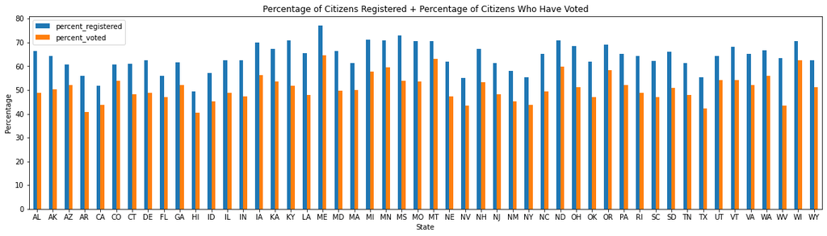

```python
ax = voting_with_wellbeing_scores.plot.bar(rot=0, figsize=(20,5), x='abbreviation', y=['percent_registered', 'percent_voted'])
ax.set_xlabel("State")
ax.set_ylabel("Percentage")
ax.set_title("Percentage of Citizens Registered + Percentage of Citizens Who Have Voted")
```

Morever, since we are mainly examining proportion of registered citizens who have voters, we decided to create a scatter plot, so that we can see if there are any interesting patterns amongst the proportions. Truthfully, not much can be gained from this scatterplot. We do see that the proportions seem to range between 65% and 90%. However, this proportion data without any metric to contrast it against, is not very useful. Perhaps, analyzing this proportion in tandem with other wllbeing characteristics would provide greater insight.

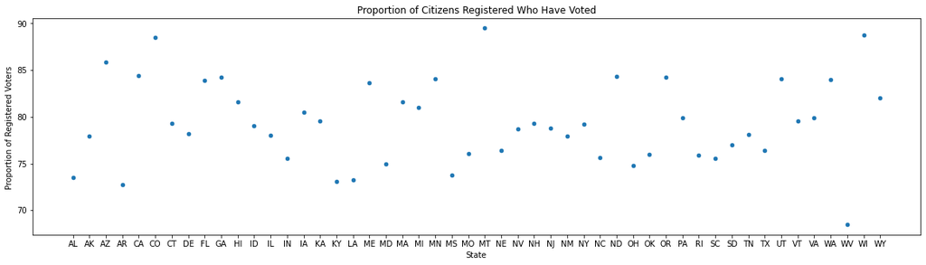

```python
ax = voting_with_wellbeing_scores.plot.scatter(rot=0, figsize=(20,5), x='abbreviation', y=['proportion_registered_who_voted'])
ax.set_xlabel("State")
ax.set_ylabel("Proportion of Registered Voters ")
ax.set_title("Proportion of Citizens Registered Who Have Voted")
```

Next, let us visualize the wellbeing data. Though the bar graph we created above does describe the reistration and voting data for each state well, it is also pretty cramped because it has to accomodate all fifty states. This means that it would not be sensible to create another bar graph where each state has a bar denoting wellbeing index, because the bar chart would be extremely difficult to read. Furthermore, upon pondering what visual representation would be best to use, we realized that there may be patterns to be found based on the geographic location of the states. For example, could New England states consistently have high healthcare scores? If so, could we investigate whether New England states vote similarily?

With this thought in mind, we decided to create maps of the United States with the Folium and Geopandas libraries. In order to do so, we found a Geojson file online which contains the locations of each of the states. Then, for each state, we provided the voting percentage and the score of the specific wellbeing characteristic. As we mentioned before, it would not be good practice to visualize of the wellbeing data in the same plot, so we will be creating a new map for every characteristic.

```python
geojson = gpd.read_file(r'georef-united-states-of-america-state-millesime.geojson')
geojson=geojson[['ste_name','geometry']] #get the geojson data we need!

# make a map of the United States
m = folium.Map(width=500, height=500, location=[48, -102], zoom_start=3)

# create the chloropleth map, by passing in voting percentages and happiness score.
folium.Choropleth(
    geo_data=r'georef-united-states-of-america-state-millesime.geojson',
    name="choropleth",
    data=voting_with_wellbeing_scores,
    columns=["state", "happiness_score"],
    key_on="feature.properties.ste_name", #bind geojson data to state name
    fill_color="YlGn",
    fill_opacity=0.7,
    line_opacity=0.2,
    legend_name="Happiness Score",
).add_to(m)
folium.LayerControl().add_to(m)

m
# voting_with_wellbeing_scores
```

Make this Notebook Trusted to load map: File -> Trust Notebook

[interactive chart not shown]

This map displays happiness scores across the United States. It appears that the happiness scores of most states range between 47% and 53%. Minnesota and Utah are the states with highest happiness scores ranging between 66% and 73%. West Virginia, Oklahoma, Arkansas, Louisiana, and Alabama are the states with the lowest happiness scores ranging between 34% to 41%.

```python
geojson = gpd.read_file(r'georef-united-states-of-america-state-millesime.geojson')
geojson=geojson[['ste_name','geometry']] #get the geojson data we need!

# make a map of the United States
m = folium.Map(width=500, height=500, location=[48, -102], zoom_start=3)

# create the chloropleth map, by passing in voting percentages and livability score.
folium.Choropleth(
    geo_data=r'georef-united-states-of-america-state-millesime.geojson',
    name="choropleth",
    data=voting_with_wellbeing_scores,
    columns=["state", "livability_score"],
    key_on="feature.properties.ste_name",
    fill_color="YlGn",
    fill_opacity=0.7,
    line_opacity=0.2,
    legend_name="Livability Score",
).add_to(m)
folium.LayerControl().add_to(m)

m
```

Make this Notebook Trusted to load map: File -> Trust Notebook

[interactive chart not shown]

The map above displays livability scores across the United States. It appears that the livability scores range between 39% and 63%, but there are three big clusters: one cluster of states have scores ranging from 55% to 63%, a second cluster have scores ranging from 47% to 55%, and a third cluster have score ranging from most states 39% to 47%.

```python
geojson = gpd.read_file(r'georef-united-states-of-america-state-millesime.geojson')
geojson=geojson[['ste_name','geometry']] #get the geojson data we need!

# make a map of the United States
m = folium.Map(width=500, height=500, location=[48, -102], zoom_start=3)

# create the chloropleth map, by passing in voting percentages and stress score.
folium.Choropleth(
    geo_data=r'georef-united-states-of-america-state-millesime.geojson',
    name="choropleth",
    data=voting_with_wellbeing_scores,
    columns=["state", "stress_score"],
    key_on="feature.properties.ste_name",
    fill_color="YlOrRd",
    fill_opacity=0.7,
    line_opacity=0.2,
    legend_name="Stress Score",
).add_to(m)
folium.LayerControl().add_to(m)

m
```

Make this Notebook Trusted to load map: File -> Trust Notebook

[interactive chart not shown]

This map displays stress scores across the United States. States with high stress scores mean that their citizens live with a higher level of stress, which is a negative. In order to show this, we changed the scale so it ranged from yellow to red instead of yellow to green. It appears that the stress scores range between 32% and 61%, but there are two big clusters: one cluster of states have scores ranging from 32% to 47%, and another cluster have scores ranging from 47% to 61%. Interestingly, it apepars that these clusters are along the North-South divide in the United States, with northern states tending to have a lower stress score, and southern states tending to have a higehr stress score. It's also really interesting, because when we compare this to the livability map they appear to mirror each other! This makes sense intuitively: the better one's living situation is, the less stressed they are.

```python
geojson = gpd.read_file(r'georef-united-states-of-america-state-millesime.geojson')
geojson=geojson[['ste_name','geometry']] #get the geojson data we need!

# make a map of the United States
m = folium.Map(width=500, height=500, location=[48, -102], zoom_start=3)

# create the chloropleth map, by passing in voting percentages and wealth gap score.
folium.Choropleth(
    geo_data=r'georef-united-states-of-america-state-millesime.geojson',
    name="choropleth",
    data=voting_with_wellbeing_scores,
    columns=["state", "wealth_gap_score"],
    key_on="feature.properties.ste_name",
    fill_color="YlOrRd",
    fill_opacity=0.7,
    line_opacity=0.2,
    legend_name="Wealth Gap Between Races",
).add_to(m)
folium.LayerControl().add_to(m)

m
```

Make this Notebook Trusted to load map: File -> Trust Notebook

[interactive chart not shown]

This map displays wealth gap scores across the United States. States with high wealth gap scores mean that they have higher economic racial inequality, which is a negative. Thus, as with the previous plot, we changed the scale so it ranged from yellow to red. It appears that most states have wealth gap scores ranging between 19% and 68%, though there is a cluster of states in the central north, that have scores ranging from 51% to 68%.

```python
geojson = gpd.read_file(r'georef-united-states-of-america-state-millesime.geojson')
geojson=geojson[['ste_name','geometry']] #get the geojson data we need!

# make a map of the United States
m = folium.Map(width=500, height=500, location=[48, -102], zoom_start=3)

# create the chloropleth map, by passing in voting percentages and healthcare score.
folium.Choropleth(
    geo_data=r'georef-united-states-of-america-state-millesime.geojson',
    name="choropleth",
    data=wellbeing_scores,
    columns=["state", "healthcare_score"],
    key_on="feature.properties.ste_name",
    fill_color="YlGn",
    fill_opacity=0.7,
    line_opacity=0.2,
    legend_name="Healthcare Score",
).add_to(m)
folium.LayerControl().add_to(m)

m
```

Make this Notebook Trusted to load map: File -> Trust Notebook

[interactive chart not shown]

This map displays healthcare gap scores across the United States. It appears that states have healthcare scores ranging between 41% and 68%, though there appear to be two clusters: one cluster of states have scores ranging from 41% to 50% and the other cluster of states have scores ranging from 50% to 59%. Some states like Minnesota, Maryland, and Massachusetts are exceptions with scores ranging from 63% to 68%.

### Data Analysis ~ Let us examine voting and wellbeing!

Now, that we have examine both the voting percentages and wellbeing data in detail, let us examine them in tandem to see if there are any intereesting patterns.

Just to provide various perspectives on this examination, we have elected to include both a bar graph and a scatterplot. The bar graph depicts the states in order, from highest wellbeing score to lowest, and presents their voting percentage data. This is one way to to see if there is any patterns related to having a higher score versus lower score.

We also decided to include the scatterplot; the scatterplot depicts the wellbeing characteristic score on the x-axis and the voting percentage on the y-axis. Note, that since we are only using data from 1 year, we cannot make any presumptive claims on causation. If there does appear to be a trend in the data, the most we will say is that it is correlated. We also decided to do fit a linear regression model on each of the scatterplots to get their coefficient and r-values.

```
R-squared value is 0.2919008054845902
The slope of the regression line is 0.28919076771803687
```

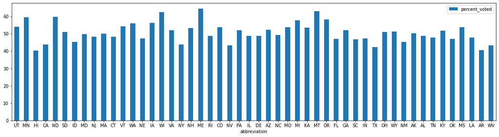

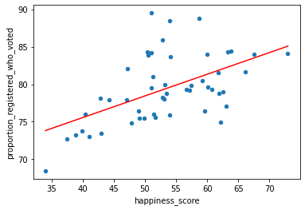

```python
voting_with_wellbeing_scores.sort_values('happiness_score', inplace=True)
voting_with_wellbeing_scores = voting_with_wellbeing_scores[::-1]
voting_with_wellbeing_scores.reset_index(drop=True, inplace=True)

ax1 = voting_with_wellbeing_scores.plot.bar(rot=0, figsize=(20,5), x='abbreviation', y=['percent_voted'])
ax2 = voting_with_wellbeing_scores.plot.scatter(x='happiness_score', y='proportion_registered_who_voted')

ind = [[i] for i in voting_with_wellbeing_scores['happiness_score'].tolist()]
dep = voting_with_wellbeing_scores['proportion_registered_who_voted'].tolist()

lm = linear_model.LinearRegression()
lm.fit(ind, dep)
ax2.plot(ind, lm.predict(ind), color='red')
r_squared = lm.score(ind, dep)
print("R-squared value is " +str(r_squared))
print("The slope of the regression line is " +str(lm.coef_[0]))
```

To quickly restate, we are hypothesizing that there may be a correlation between wellbeing characteristics, like happiness scores, and the proportion of registered voters.

```
R-squared value is 0.21509597822595095
The slope of the regression line is 0.34058131980585604
```

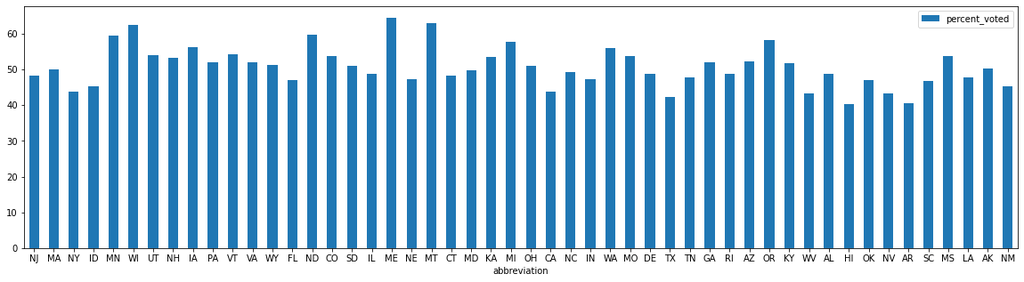

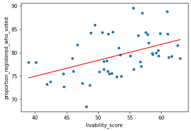

```python
voting_with_wellbeing_scores.sort_values('livability_score', inplace=True)
voting_with_wellbeing_scores = voting_with_wellbeing_scores[::-1]
voting_with_wellbeing_scores.reset_index(drop=True, inplace=True)


ax1 = voting_with_wellbeing_scores.plot.bar(rot=0, figsize=(20,5), x='abbreviation', y=['percent_voted'])
ax2 = voting_with_wellbeing_scores.plot.scatter(x='livability_score', y='proportion_registered_who_voted')

ind = [[i] for i in voting_with_wellbeing_scores['livability_score'].tolist()]
dep = voting_with_wellbeing_scores['proportion_registered_who_voted'].tolist()

lm = linear_model.LinearRegression()
lm.fit(ind, dep)
ax2.plot(ind, lm.predict(ind), color='red')
r_squared = lm.score(ind, dep)
print("R-squared value is " +str(r_squared))
print("The slope of the regression line is " +str(lm.coef_[0]))
```

Again, to quickly restate, we are hypothesizing that there may be a correlation between wellbeing characteristics. Thus let us examine whether there is a relationship between livability scores, and the proportion of registered voters.

As we described before, the two plots above display livability scores in different ways. From the bar plot, we can see that there is higher variability in the proportion of registered citizens who have voted amongst the states, so we cannot draw any meaningful conclusions from here. Furthermore, the scatterplot was fitted with a linear regression model. The linear regression line displayed shows a slight positive trend such that the better a state is to live in, the more likely its citizens are to vote. The coefficient of the linear regression line is 0.34, which does not mean that the hypothesis that livability scores and proportion of registered voters are correlated is automatically rejected, since the coefficient is not close to 0. The r-squared value, which describes how well the linear regression line fits the data, is 0.22. Since the r-squared value is low, this relationship requires further testing.

### stress appears to have some slight downward trend

```
R-squared value is 0.24934899472868854
The slope of the regression line is -0.3161447465986976
```

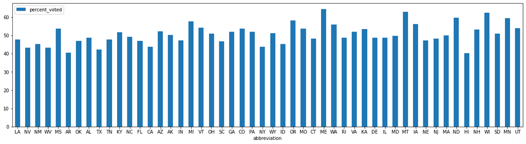

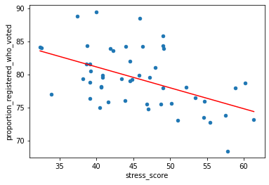

```python
voting_with_wellbeing_scores.sort_values('stress_score', inplace=True)
voting_with_wellbeing_scores = voting_with_wellbeing_scores[::-1]
voting_with_wellbeing_scores.reset_index(drop=True, inplace=True)

ax1 = voting_with_wellbeing_scores.plot.bar(rot=0, figsize=(20,5), x='abbreviation', y=['percent_voted'])
ax2 = voting_with_wellbeing_scores.plot.scatter(x='stress_score', y='proportion_registered_who_voted')

ind = [[i] for i in voting_with_wellbeing_scores['stress_score'].tolist()]
dep = voting_with_wellbeing_scores['proportion_registered_who_voted'].tolist()

lm = linear_model.LinearRegression()
lm.fit(ind, dep)
ax2.plot(ind, lm.predict(ind), color='red')
r_squared = lm.score(ind, dep)
print("R-squared value is " +str(r_squared))
print("The slope of the regression line is " +str(lm.coef_[0]))
```

Next, we will examine whether there is a relationship between stress scores and the proportion of registered voters. From the bar plot, we can see that though there is variability in the proportion of registered citizens who have voted amongst the states, there does appear to be a slight increase in the proportion as the stress scores go down. However, it is also possible that there is not significant trend and that states like Maine, Montana, North Dakota, etc. with low stress scores and high proportions may also be outliers.

The scatterplot was again fitted with a linear regression model. The linear regression line displayed shows a slight negative trend such that the lower the stress level in a state, the more likely its citizens are to vote. This matches what we saw in the bar graph! The coefficient of the linear regression line is -0.32, which does not mean that the hypothesis that stress scores and proportion of registered voters are correlated is automatically rejected, since the coefficient is not close to 0. The r-squared value, which describes how well the linear regression line fits the data, is 0.25. Since the r-squared value is low, this relationship requires further testing.

```
R-squared value is 0.004771841925075071
The slope of the regression line is 0.029938614864062615
```

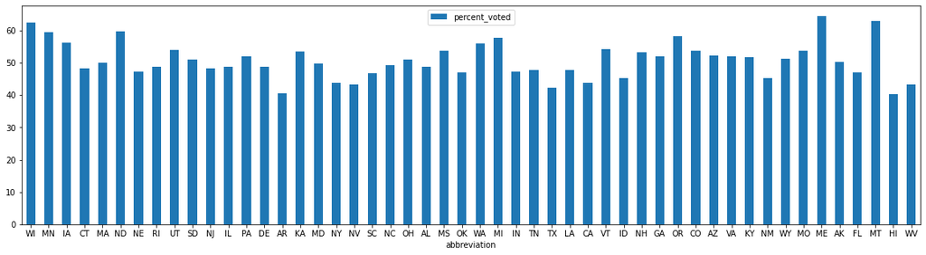

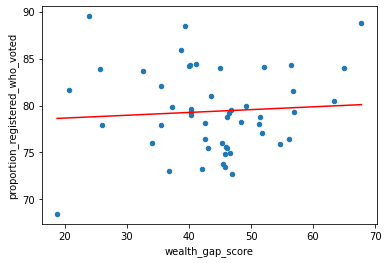

```python
voting_with_wellbeing_scores.sort_values('wealth_gap_score', inplace=True)
voting_with_wellbeing_scores = voting_with_wellbeing_scores[::-1]
voting_with_wellbeing_scores.reset_index(drop=True, inplace=True)

ax1 = voting_with_wellbeing_scores.plot.bar(rot=0, figsize=(20,5), x='abbreviation', y=['percent_voted'])
ax2 = voting_with_wellbeing_scores.plot.scatter(x='wealth_gap_score', y='proportion_registered_who_voted')

ind = [[i] for i in voting_with_wellbeing_scores['wealth_gap_score'].tolist()]
dep = voting_with_wellbeing_scores['proportion_registered_who_voted'].tolist()

lm = linear_model.LinearRegression()
lm.fit(ind, dep)
ax2.plot(ind, lm.predict(ind), color='red')
r_squared = lm.score(ind, dep)
print("R-squared value is " +str(r_squared))
print("The slope of the regression line is " +str(lm.coef_[0]))
```

Next, we will examine whether there is a relationship between wealth gap/inequality between races and the proportion of registered voters. From the bar plot, we can see that there is higher variability in the proportion of registered citizens who have voted amongst the states, so we cannot draw any meaningful conclusions from here.

When the scatterplot was fitted with a linear regression model, the linear regression line displayed shows a very very slight positive trend. However, the coefficient of the linear regression line is 0.03; since the coefficient is so clsoe to 0, we will be rejecting the hypothesis that that wealth gap scores and proportion of registered voters are correlated. The r-squared value further displays how the linear regression line does not fit the data since it is 0.004. Since both the linear regression coefficient and r-squared values are so low, it is unlikely that there is a relationship; if there is one, it is very weak.

```
R-squared value is 0.1394659512827341
The slope of the regression line is 0.25901308169579224
```

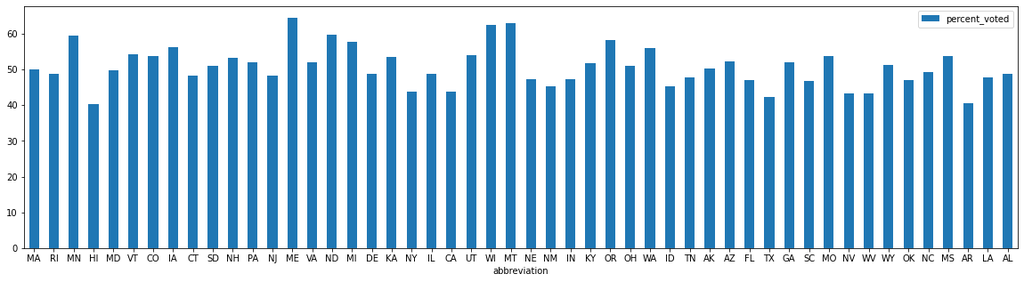

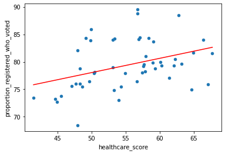

```python
voting_with_wellbeing_scores.sort_values('healthcare_score', inplace=True)
voting_with_wellbeing_scores = voting_with_wellbeing_scores[::-1]
voting_with_wellbeing_scores.reset_index(drop=True, inplace=True)

ax1 = voting_with_wellbeing_scores.plot.bar(rot=0, figsize=(20,5), x='abbreviation', y=['percent_voted'])
ax2 = voting_with_wellbeing_scores.plot.scatter(x='healthcare_score', y='proportion_registered_who_voted')

ind = [[i] for i in voting_with_wellbeing_scores['healthcare_score'].tolist()]
dep = voting_with_wellbeing_scores['proportion_registered_who_voted'].tolist()

lm = linear_model.LinearRegression()
lm.fit(ind, dep)
ax2.plot(ind, lm.predict(ind), color='red')
r_squared = lm.score(ind, dep)
print("R-squared value is " +str(r_squared))
print("The slope of the regression line is " +str(lm.coef_[0]))
```

Finally, we will examine whether there is a relationship between healthcare scores and the proportion of registered voters. From the bar plot, we can see that there is higher variability in the proportion of registered citizens who have voted amongst the states, so we cannot draw any meaningful conclusions from here.

When the scatterplot was fitted with a linear regression model, the linear regression line displayed shows a very slight positive trend such that the better healthcare a state has, the more likely its registered citizens are to vote. The coefficient of the linear regression line is 0.26, which does not mean that the hypothesis that stress scores and proportion of registered voters are correlated is automatically rejected, since the coefficient is not close to 0. However, the r-squared value displays how the linear regression line does not fit the data since it is 0.14. Since the r-squared value is so low, it is unlikely there is a relationship, or if there is, it is very weak.

### Insights

French et al. (2014) further supports these tentative findings regarding the relationship between voting and stress scores. They found that increased cortisol levels represented increased stress, and their results noted that increased cortisol levels led to decreased probability of voting. My results agreed with their findings.

We also found some research supporting our findings regarding happiness scores. The 2019 World Happiness Report discussed how voter life satisfaction in European countries had a statistically significant relationship with cabinet vote share (Ward 2019). Even through five different models, voter well-being had a positive relationship to cabinet vote share, with p-value < 0.01 in all five cases. Our data showed a comparable trend with a positive relationship between state happiness score and the proportion of registered who voted.

Works Cited: French, J. A., Smith, K. B., Alford, J. R., Guck, A., Birnie, A. K., & Hibbing, J. R. (2014). Cortisol and politics: variance in voting behavior is predicted by baseline cortisol levels. Physiology & behavior, 133, 61-67. Accessed 16 May 2022, from https://www.sciencedirect.com/science/article/pii/S0031938414002595. Ward, G. (2019). Happiness and voting behaviour. World Happiness Report 2019, 46-65.

### Further research Paths: Data analysis could include looking at the elections themselves!

#### Perhaps it's not the quality of life but more about the election itself? (# https://www.brennancenter.org/our-work/research-reports/voting-laws-roundup-may-2021)

The below code is incomplete but if further worked upon, it could examine the factors related to percentage of voting beyond quality of life. The way elections are run impacts how voters percieve not just the election, but also the government institutions they are voting for. Elections can also make it less or more difficult for citizens to vote.

The two things we start to look at here are the restrictive and expansive voting laws, as well as registration deadlines. With more time, we would examine whether states with a higher ratio of expansive tor restrictive laws passed/in motion is correlated with voting percentages. Similarily, in regards to registration deadlines, we could examine if the less stringent a state's registration deadline is, the more its citizens vote.

```python
voting_law_scores = pd.read_csv('data/law_scores.csv', names=['state','expansive laws passed', 'expansive laws moving', 'restrictive laws passed', 'restrictive laws moving'])
voting_law_scores.head(5)
```

```python
scores = []
for index in voting_law_scores.index:
    exp = voting_law_scores.iloc[index, 1] + voting_law_scores.iloc[index, 2]
    res = voting_law_scores.iloc[index, 3] + voting_law_scores.iloc[index, 4]
    scores.append(exp-res)

voting_law_scores.insert(1, "score", scores, True)
voting_law_scores.head(5)
```

```python
voting_law_scores = voting_law_scores[['state', 'score']]
voting_law_scores = pd.merge(voting_percentages, voting_law_scores, how='left', on=['state'])
# voting_with_wellbeing_scores = pd.merge(voting_with_wellbeing_scores, registration_deadlines,  how='left', on=['state'])
voting_law_scores.head(5)
```

```python
ax = voting_law_scores.plot.scatter(x ='score', y ='percent_voted')
```

[output not shown]

```python
registration_deadlines = pd.read_csv('data/voting_registration_deadlines.csv', names=['state','days before election'])
registration_deadlines.head(5)
```

```python
# https://www.ncsl.org/research/elections-and-campaigns/voter-registration-deadlines.aspx#table%201
voting_with_scores = pd.merge(voting_with_scores, registration_deadlines,  how='left', on=['state'])
ax2 = voting_with_scores.plot.scatter(x ='days before election', y ='percent_voted')

#slight negative trend???
```

[output not shown]

```python
idx = pd.IndexSlice
state_perc_registered = voting_df.loc[idx[:,'Total'],'%voted'].to_list()[1:]
wellbeing_cols = ['well-being_index','career','social','financial','community','physical']

for x in wellbeing_cols:
    state_wellbeing = wellbeing[x].to_list()
    plt.scatter(state_perc_registered, state_wellbeing)
    plt.xticks([10,20,30,40,50,60])
    plt.show
```